# Estimating Parameters of Probability Distributions

László Kovács

01/03/2025

## 1. Method of Moments

In Chapter 5, we’ve covered the properties describing the behavior of **estimators for classical statistical measures**. Like how to **estimate the population mean, standard deviation, proportions, median etc. with their values calculated from sample data**.  
What this chapter covers is **estimating the parameters of probability distributions from sample data alone**. Like we **assume that our observed sample data follows a specific probability distribution** (Binomial, Poisson, Normal, Exponential, etc.) and we want to **determine the parameter values that best fit our data**.  
So, if we somehow know or suspect (e.g. from a histogram) that our data has Binomial Distributions, then what are the $n$ and $p$ parameter that best fit for our data. Or if our data is assumed to have Exponential distribution, then what is the $\lambda$ that best fits our observed sample data.

We have two basic ways to solve this problem. The first way we cover is the simpler one: the **method of moments**. And We’ll soon see that **actually we’ve used this method in previous chapters**, we just did not know it. :)

The concept is what we have used for normal distribution in case of the Tesla price change data in Chapter 3. For a normal distribution $Y \sim N(\mu, \sigma)$ we say that the **sample moments are the best estimators for the theoretical moments**: $\hat{\mu}=\bar{y}$ and $\hat{\sigma}^2=s^2$

In a more general sense, we calculate the **first non-centered moment and the second or above centered moments** from the observed sample data with the **formulas we’ve covered on the Fundamentals of Statistics course**. The only modification is that we **divide with $n-1$ instead of $n$** as this why we have **unbiased estimates** for the second or above centered moments. We’ve seen this in the case of the variance in Section 3 of Chapter 5.

- First non-centered moment: $\hat{M_1}=\bar{y}=\frac{\sum_{i=1}^n{y_i}}{n}$
- Second centered moment: $\hat{M_2}=s^2=\frac{\sum_{i=1}^n{(y_i-\bar{y})^2}}{n-1}$
- Third centered moment: $\hat{M_3}=\frac{\sum_{i=1}^n{(y_i-\bar{y})^3}}{n-1}$
- Fourth centered moment: $\hat{M_4}=\frac{\sum_{i=1}^n{(y_i-\bar{y})^4}}{n-1}$

Then, we **assume that these moments of the sample match with their theoretical values in the probability distribution** we want to fit on the observed data.

- Theoretical first non-centered moment: $M_1=E(Y)$
- Theoretical second centered moment: $M_2=\sigma^2=E((Y-E(Y)^2)$
- Theoretical third centered moment: $M_3=E((Y-E(Y)^3)$
- Theoretical fourth centered moment: $M_4=E((Y-E(Y)^4)$

These **theoretical moments given above can be expressed with the parameters of the distribution** we want to fit on the observed sample. So, if the assume that these theoretical values are equal with their $\hat{M_i}$ values calculated from the sample, then we can **solve the system of equations $M_i = \hat{M_i}$ for the distribution parameters**. If **we have $p$ parameters to determine, we use the first $i=1,2,...,p$ moments** for the $M_i = \hat{M_i}$ equations.  
Usually we examine probability distributions with a maximum of only two parameters, so usually only the mean and variance are used. But if we fit a distribution with $p=3$ parameters, then we can also utilize the third centered moment (skewness times $\sigma^3$) as well.

Therefore, in the case of the $N(\mu, \sigma)$ distribution, we have that $E(Y)=\mu$ and $Var(Y)=\sigma^2$, so we can just say that $\hat{\mu}=\bar{y}$ and $\hat{\sigma}=s$. Because this is the solution of the $M_i = \hat{M_i}$ equations for $i=1,2$. And **this is what we did when we fitted the normal distribution on the Tesla price changes data** in Chapter 3.

Now, let’s see the method of moments in action for other probability distributions!

### 1.1. Bernoulli and Poisson Distributions

Read the data in the insurance_examples.xlsx file.  
On the worksheet titled *CarInsurance_IsClaim*, we can find an insurance company’s $500$ insured cars and the fact whether they caused an accident (claim) in the past year (1=yes and 0=no) in the *IsClaim* column.  
On the worksheet titled *CarInsurance_NumberOfClaims*, we can find another insurance company’s $400$ insured cars and the number of accidents (claims) they caused in the past year in the *NumClaims* column.  
Read both wotksheets into two separate data frames using the `sheet` parameter in the `read_excel` function of the `readxl` package.

```r
library(readxl)
is_claim <- read_excel("insurance_examples.xlsx", sheet = "CarInsurance_IsClaim")
num_claims <- read_excel("insurance_examples.xlsx", sheet = "CarInsurance_NumberOfClaims")

# Check the results!
str(is_claim)
```

```
## tibble [500 x 2] (S3: tbl_df/tbl/data.frame)
##  $ InsuredID: num [1:500] 1 2 3 4 5 6 7 8 9 10 ...
##  $ IsClaim  : num [1:500] 0 0 0 0 0 0 0 0 0 0 ...
```

```r
str(num_claims)
```

```
## tibble [400 x 2] (S3: tbl_df/tbl/data.frame)
##  $ InsuredID: num [1:400] 1 2 3 4 5 6 7 8 9 10 ...
##  $ NumClaims: num [1:400] 0 0 1 1 0 2 0 0 1 0 ...
```

Let’s introduce the notation $IsClaim=X$ and $NumClaims=Y$. For $X$, a Bernoulli distribution is a good assumption as its outcomes can only be $0$ and $1$. For $Y$, Poisson distribution is a reasonable assumption as the number of claims can only be integers (discrete distribution) and there is no theoretical maximum value for the number of accidents to have in one year, so the outcomes can be any non negative integers $0,1,2,...,\infty$.

With this reasoning, **we have $X \sim I(p)$ and $Y ~ P(\lambda)$, then we know that $E(X)=p$ and $E(Y)=\lambda$.**

With the `is_claim` and `num_claims` data frames, **we have an IID sample of size $n$ from both distributions**. The sample observations defined as $y=(y_1,y_2,...,y_n)$ and $x=(x_1,x_2,...,x_n)$ respectively. Of course, $n=500$ for $x$ and $n=400$ for $y$.
The sample means $\bar{x}$ and $\bar{y}$ are the “*sample versions*” of the expected values of two distributions. So we can simply say that the sample mean of $x$ (denoted as $\hat{x}$) is an estimator of $p$ (denoted as $\hat{p}$):
$$\bar{x}=\hat{p}$$

And of course, we can also say that the sample mean of $y$ is an estimator of $p$:
$$\bar{y}=\hat{\lambda}$$

And at this point, we can just do the estimation with the method of moments as described above for both variables.

```r
p_estim <- mean(is_claim$IsClaim)
lambda_estim <- mean(num_claims$NumClaims)
p_estim
```

```
## [1] 0.018
```

```r
lambda_estim
```

```
## [1] 0.71
```

We can see the goodness of fit for the Bernoulli Distribution by comparing the sample’s observed frequencies with the **expected frequencies calculated from the mass function of the Bernoulli distribution**. The expected frequencies can simply be calculated as the probabilities of the sample values occurring in the fitted Bernoulli distribution times the sample size: $P(X=x_i) \times n$.  
The mass function of the Bernoulli distribtion is not defined in R, but it’s simply $p$ for the $1$s and $1-p$ for the $0$s.

```r
observed_frequencies <- table(is_claim$IsClaim)
expected_frequencies <- c(p_estim*nrow(is_claim), (1-p_estim)*nrow(is_claim))
names(expected_frequencies) <- c("1", "0")

observed_frequencies
```

```
##
##   0   1
## 491   9
```

```r
expected_frequencies
```

```
##   1   0
##   9 491
```

It’s a perfect fit, we’ve done well! :)

See the goodness of fit for the Poisson Distribution too by comparing the sample’s observed frequencies with the **expected frequencies calculated from the mass function of the Poisson distribution**. The formula for the expected frequencies is the same as before, $P(Y=y_i) \times n$, but now we can use the `dpois` R function for calculating the mass function values (the $P(Y=y_i)$ probabilities) for the Poisson distribution.

```r
observed_frequencies <- table(num_claims$NumClaims)
expected_frequencies <- round(dpois(x = unique(num_claims$NumClaims), lambda = lambda_estim) * nrow(num_claims), 0)
names(expected_frequencies) <- names(observed_frequencies)

observed_frequencies
```

```
##
##   0   1   2   3   4
## 191 150  46  10   3
```

```r
expected_frequencies
```

```
##   0   1   2   3   4
## 197 140  50  12   2
```

### 1.2. Binomial Distribution

A more advanced case for Binomial distribution as in this case, we have **two parameters to fit**. Let’s say that we have an insurance portfolio for car fleets of small businesses with a maximum number of $m$ cars. The *CarInsurance_Fleet* sheet of the *insurance_examples.xlsx* file contains $150$ insured car fleets and the `NumClaims_Fleet` variable (column) shows the number of cars with accidents reported in a given year for each fleet.  
Let’s read the data on this worksheet to a data frame with the same function as before!

```r
carinsurance_fleet <- read_excel("insurance_examples.xlsx", sheet = "CarInsurance_Fleet")
str(carinsurance_fleet)
```

```
## tibble [150 x 2] (S3: tbl_df/tbl/data.frame)
##  $ InsuredID      : num [1:150] 1 2 3 4 5 6 7 8 9 10 ...
##  $ NumClaims_Fleet: num [1:150] 1 0 1 0 0 0 1 0 2 0 ...
```

If each car has a probability of $p$ to have an accident in a year, then we can say that the number of claims reported in a fleet (let’s denote this variable as $X$) has a Binomial Distribution: $X \sim B(m,p)$  
The **Binomial distribution is reasonable here as no car fleet can have more cars with accidents than their total number of $m$ cars**.

This time, we have two parameters to estimate: $m$ and $p$. Here we need two equations to determine the two parameters. We can use the definitions for the expected value and variance (first two moments): $E(X)=np$ and $Var(X)=np(1-p)$. These theoretical definitions can also be assumed to hold in the observed IID sample too. So, the **two equations to solve** for $n$ and $p$ are:
$$\bar{x}=\hat{n}\hat{p}$$

And of course:
$$s^2=\hat{n}\hat{p}(1-\hat{p})$$

We use the corrected sample variance, $s^2$ here of course, as we should not underestimate the second moment.

To solve this system of two equations, we should first substitute the first equation into the second one:
$$s^2=\bar{x} \times (1-\hat{p})$$

This, we can solve for $\hat{p}$:
$$\hat{p}=1-\frac{s^2}{\bar{x}}$$

We can try this formula rather easily in R.

```r
p_binom_estim <- 1-var(carinsurance_fleet$NumClaims_Fleet)/mean(carinsurance_fleet$NumClaims_Fleet)
p_binom_estim
```

```
## [1] 0.0783203
```

Great, we have that $\hat{p}=0.078$ for our data.

With $\hat{p}$, it’s easy to obtain $\hat{n}$ from the first equation:
$$\hat{n}=\frac{\bar{x}}{\hat{p}}$$

In R, we just simply follow this formula above as well.

```r
n_binom_estim <- mean(carinsurance_fleet$NumClaims_Fleet)/p_binom_estim
n_binom_estim
```

```
## [1] 9.278139
```

As $n$ must be an integer, we should round the result for $\hat{n}$. if we aim to be cautious (in other words prudent), then we take the highest possible value on the maximum number of the claims, so we round $\hat{n}$ to $10$.

```r
n_binom_estim <- ceiling(n_binom_estim)
n_binom_estim
```

```
## [1] 10
```

See the goodness of fit for the Binomial Distribution by comparing the sample’s observed frequencies with the **expected frequencies calculated from the mass function of the Binomial distribution**. The formula for the expected frequencies is the same as before, $P(X=x_i) \times n$, but now we can use the `dbinom` R function for calculating the mass function values (the $P(X=x_i)$ probabilities) for the Binomial distribution.

```r
observed_frequencies <- table(carinsurance_fleet$NumClaims_Fleet)
expected_frequencies <- round(dbinom(x = unique(carinsurance_fleet$NumClaims_Fleet),
                                     size = n_binom_estim, prob = p_binom_estim) *
                                nrow(num_claims), 0)
names(expected_frequencies) <- names(observed_frequencies)

observed_frequencies
```

```
##
##  0  1  2  3  4
## 71 53 23  2  1
```

```r
expected_frequencies
```

```
##   0   1   2   3   4
## 150 177  57   2  13
```

### 1.3. Exponential Distribution

For the continuous distributions, let’s see the Exponential Distribution as an example.

Examine the chemotherapy survival times found in the [CancerSurvival.xlsx](https://github.com/KoLa992/Statistical-Modelling-Lecture-Notes/blob/main/CancerSurvival.xlsx\) file again.

```r
Surv <- read_excel("CancerSurvival.xlsx")
str(Surv)
```

```
## tibble [58 x 2] (S3: tbl_df/tbl/data.frame)
##  $ ID       : chr [1:58] "1." "2." "3." "4." ...
##  $ SurvMonth: num [1:58] 6.53 7 10.42 14.48 16.1 ...
```

If we remember for the histogram of this data, it has quite a long right tail and the survival times can take any non negative real values (continuous distribution), so the Exponential distribution would be a good assumption here.

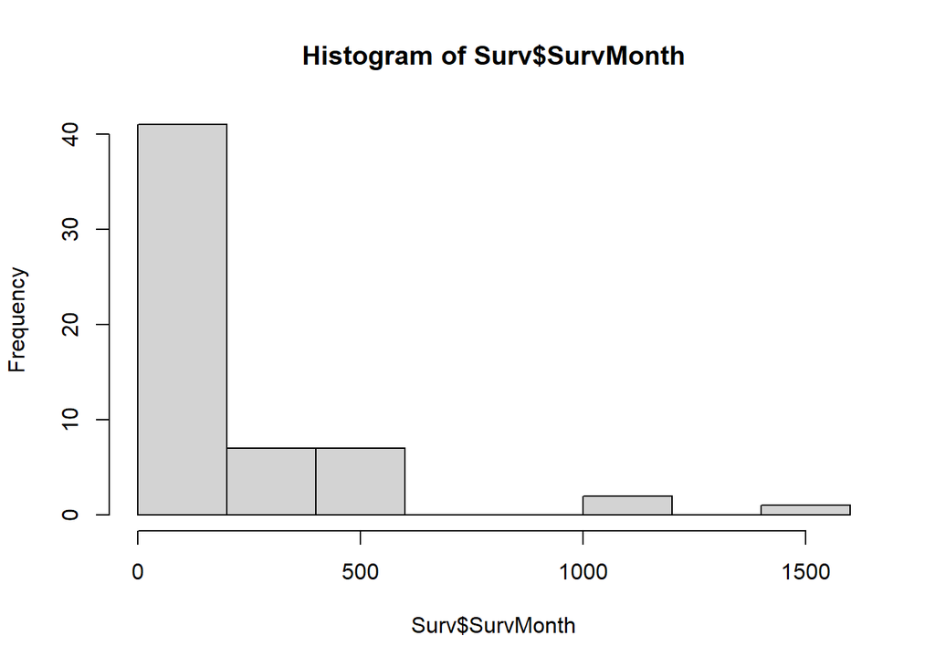

```r
hist(Surv$SurvMonth)
```

If we have $Y \sim Exp(\lambda)$, then the expected value is $E(Y)=\frac{1}{\lambda}$, so if this is true in the sample as well, then the equation to solve is:
$$\bar{y}=\frac{1}{\hat{\lambda}}$$

This solution is just a reciprocal, so:
$$\hat{\lambda}=\frac{1}{\bar{y}}=\frac{n}{\sum_{i=1}^{n}{y_i}}$$

So, as we did in Chapter 3, let’s take the reciprocal of the sample mean, and we’ll have the same $Exp(0.00442)$ distribution again for the cancer survival times.

```r
1/mean(Surv$SurvMonth)
```

```
## [1] 0.004421379
```

Very nice same result as in Chapter 3.  
However, this logic raises an **issue**: why not have $\hat{\lambda}=\frac{1}{s}$? As for the Exponential distribution we also have that $\sqrt{M_2}=\sqrt{Var(Y)}=\frac{1}{\lambda}$. From the general principles of the method of moments, it follows that we only need the first non centered moment, $M_1$ if we only have $1$ parameter to estimate. But in the case of the Exponential distribution, it is an interesting question why is it a better choice to express $\hat{\lambda}$ from the sample mean than from the corrected sample standard deviation. The answer will come from the other method for estimating parameters of probability distributions: the maximum likelihood method!

## 2. Maximum Likelihood Estimation

The **method of moments** has **one** great **advantage**: its **calculations are very-very simple**! However, it **does NOT consider every observation in our sample when estimating the distribution parameters**. It only uses calculated statistical measures of our sample, its moments.  
The **maximum likelihood method uses every observation our sample directly when estimating the distribution parameters**. On the other hand, its **calculations are more complex** than those of the method of moments.  
What makes the **complexity of the maximum likelihood method worthwhile is that it is the MOST EFFICIENT estimator of the parameters of any probability distribution**. Remember from Chapter 5 that if one estimator is more efficient than another then its mean squared error (bias and standard sampling error considered together) is lower. This definition means that the maximum likelihood method produces **estimates of distribution parameters** with the **LOWEST $MSE=Bs^2+SE^2$ values**. More on this property is covered on the lectures!

Now, after seeing its benefits, let’s see the **general principles of the maximum likelihood method**.

The basic concept is quite simple: let’s **find those parameters** for a given probability distribution that **maximize the probability of all our observed data occurring in an IID sample** (i.e. random sample with replacement) from that given distribution. So, if the elements of the observed sample of size $n$ are denoted as $y=(y_1,y_2,...,y_n)$, and the parameters of the probability distribution we are looking for denoted as $\theta$, then we are looking for the $\theta$ values that maximizes the probability of $y$ occurring in case of $n$ random draws from the examined distribution.
A mathematical formulation for this task is as follows:
$$P(y|\theta) \rightarrow \max_{\theta}$$

Here, the $P(y|\theta)$ probability is called as the **likelihood of the sample**. This is the **probability** of our observed **sample occurring on the condition that we give some arbitrary values for $\theta$.** So, in other words, we are **looking for those $\theta$ conditions that maximize our $y$ sample occurring.**  
To calculate this, we can **use the $f(x,\theta)$ mass/density functions of the discrete/continuous distributions**, as they **show the probability of an arbitrary number $x$ occurring in a random draw from the probability distribution with $\theta$ parameters**. So if we say that every $y_1,y_2,...,y_n$ observations of our sample are from the same probability distribution with the same mass/density function denoted as $f$, then this function can be used to give the **probability of the a specific $y_i$ sample observations occurring in a random draw as $f(y_i, \theta)$.**

So, the **probability of each $y_i$ observation of our sample occurring for a random draw under some $\theta$ parameter conditions** is given as
$$f(y_i)=P(y_i|\theta)$$

This is the **likelihood of the $y_i$ observation**.

The **likelihood of the whole sample is the probability of all the observed $y_i$ values ($y_1,y_2,...,y_n$) occurring all at once!** This is the **PRODUCT of the $P(y_i|\theta)$ probabilities if the $y_i$ values are independent**, and since **we assume that we work with IID** (independent, identically distributed) **samples, the independence of the $y_i$ values can also be assumed**, because of the first “I” in IID. :)

Therefore, the **likelihood of our whole $y$ sample under the condition of some $\theta$ parameters in an IID sample of size $n$** is given as follows:
$$L(\theta)=\prod_{i=1}^{n}{P(y_i|\theta)}=\prod_{i=1}^{n}{f(y_i, \theta)}$$

And we need to **maximize this $L(\theta)$ by varying the $\theta$ conditions**. As this is what is the **direct expression of the maximum likelihood principle**: *find those parameters that maximize the probability of all our observed data occurring in an IID sample*.

To **solve this maximization task**, we need to take the $\frac{\partial L(\theta)}{\partial\theta}$ derivatives and make them equal to $0$. However, **taking the derivative of a product-function that is $L(\theta)$ is rather painful**. Best to avoid this. :) And thankfully we can avoid this by **maximizing the log-likelihood function of the sample**, as **on a log-scale a multiplicative function becomes an additive one!**
$$l(\theta)=\ln(L(\theta))=\ln\prod_{i=1}^{n}{f(y_i,\theta)}=\sum_{i=1}^{n}{\ln(f(y_i,\theta)})$$

So, in practice, to **make our jobs easy, we maximize the log-likelihood function in $\theta$:**
$$l(\theta) \rightarrow \max_{\theta}$$

And we can simply do this maximization by **taking the derivative of the log-likelihood** according to $\theta$ and solve the equation of **this derivative being equal to $0$:**
$$\frac{\partial l(\theta)}{\partial\theta}=0$$

Ok, great: we now know what to do to get maximum likelihood (ML) estimators. Let’s see some **practical examples** for this maximum likelihood estimation process!

### 2.1. Numerically for the Exponential Distribution

Use the Cancer survival data from Chapter 3 again for a sample where Exponenetial distribution is reasonable assumption.

The parameter to estimate for the Exponential distribution is $\lambda$. So, in the exponential case: $\theta=\lambda$.

Now, let’s write the negative log-likelihood function for our sample as a custom R function. We need the **negative log-likelihood** as the **built-in methods for optimization in R can only minimize** a function, and NOT maximize. So, we’ll **minimize the negative log-likelihood which is the same as maximizing the original log-likelihood**.  
The input parameter of the function, `theta_expon` is treated as the value for the $\lambda$ parameter of course. We can use the `dexp` function for calculating the $P(y_i|\theta)=f(y_i,\theta)$ probabilities for the Exponential distribution. Then, we just apply the $l(\theta)=\sum_{i=1}^{n}{\ln(f(y_i,\theta)})$ formula.

```r
# function definition
neg_log_likelihood_expon <- function(theta_expon){
  log_lik_observations <- log(dexp(x = Surv$SurvMonth,
                                   rate = theta_expon)) # log-probability of every observations occurring under the current parameters
  return(-sum(log_lik_observations))
}

# function test on some random parameter combination
neg_log_likelihood_expon(0.001)
```

```
## [1] 413.7679
```

Do the **optimization with R’s built-in `optim` function**. The first parameter of this function is the starting $\lambda$ value for the optimization. This value can be any arbitrary starting value, but we should respect the constraint on the Exponential parameter: $\lambda>0$. We can *ignore the possible warnings*, it just means that R encountered some bad parameter values when trying out different $\lambda$ values during the optimization. R automatically ignores these cases, they won’t cause any problems.

```r
expon_ml <- optim(0.001, neg_log_likelihood_expon)
expon_ml$par # optimal parameter value
```

```
## [1] 0.004421875
```

```r
expon_ml$val # minimized negative log-likelihood of the sample
```

```
## [1] 372.4356
```

So, our result is $\hat{\lambda}_{ML}=0.00442$. Which is the **reciprocal of the sample mean and not the standard deviation**!

```r
1/mean(Surv$SurvMonth)
```

```
## [1] 0.004421379
```

```r
1/sd(Surv$SurvMonth)
```

```
## [1] 0.003650389
```

Since the **maximum likelihood method ensures that what we got is the efficient estimator** (it has the lowest $MSE$), we can **conclude that we need to take the reciprocal of the mean and NOT the standard deviation when estimating $\lambda$ of an exponential distribution**.

### 2.3. Analitically for the Exponential Distribution

The result of *Section 2.2.* can also be derived analytically by **taking the derivative of the log-likelihood** according to $\theta$ and solve the equation of **this derivative being equal to $0$:**
$$\frac{\partial l(\theta)}{\partial\theta}=0$$

The $P(y_i|\theta)=f(y_i,\theta)$ probabilities for the Exponential distribution (where $\theta = \lambda$) are given by the Exponential density function:
$$f(y_i, \lambda)=\lambda e^{-\lambda y_i}$$

The likelihood of the whole sample is the individual $y_i$ likelihoods multiplied together because of the $y_i$s independence (IID sample):
$$L(\lambda)=\prod_{i=1}^n{\lambda e^{-\lambda y_i}}$$

We can expand the product by using the fact that multiplication becomes additive in the power:
$$L(\lambda)=\lambda^n e^{-\lambda \sum_{i=1}^n{y_i}}$$

Taking the natural logarithm of the likelihood function to produce the log-likelihood:
$$l(\lambda)=\ln(L(\lambda))=\ln(\lambda^n e^{-\lambda \sum_{i=1}^n{y_i}})$$

Using logarithm properties we can make the expression additive, so its easier to derivative:
$$l(\lambda)=n \times \ln(\lambda) - \lambda \times \sum_{i=1}^n{y_i}$$

Taking the derivative according to $\lambda$:
$$\frac{\partial l(\lambda)}{\partial\lambda}=\frac{n}{\lambda}-\sum_{i=1}^n{y_i}$$

Setting this derivative to zero:
$$\frac{n}{\lambda}=\sum_{i=1}^n{y_i}$$

And finally, solving for $\lambda$ we have:
$$\lambda=\frac{n}{\sum_{i=1}^n{y_i}}$$

So we arrived to the same conclusion as in *Section 2.2*: **the maximum likelihood estimation (MLE) for $\lambda$ is the reciprocal of the sample mean**.

### 2.4. Numerically for the Binomial Distribution

Let’s use the example of number of cars having accident in a fleet of $m$ cars from *Section 1*. We’ve discussed in *Section 1* that the Binomial distribution is a reasonable assumption for this data.

The parameters to estimate for the Binomial distribution are $m$ and $p$, so in this case: $\theta=(m,p)$

Now, let’s write the negative log-likelihood function for our sample as a custom R function in this case as well.  
The input parameter of the function, `theta_binom` is treated as a `vector` where the 1st value is the $m$ parameter and the 2nd value is the $p$ parameter. We can use the `dbinom` function for calculating the $P(y_i|\theta)=f(y_i,\theta)$ probabilities for the Binomial distribution. Then, we just apply the $l(\theta)=\sum_{i=1}^{n}{\ln(f(y_i,\theta)})$ formula.

```r
# function definition
neg_log_likelihood_binom <- function(theta_binom){
  log_lik_observations <- log(dbinom(x = carinsurance_fleet$NumClaims_Fleet,
                                     size = theta_binom[1],
                                     prob = theta_binom[2])) # log-probability of every observations occurring under the current parameters
  return(-sum(log_lik_observations))
}

# function test on some random parameter combination
neg_log_likelihood_binom(c(8, 0.1))
```

```
## [1] 166.7798
```

Do the **optimization with R’s built-in `optim` function**. The first parameter of this function are the starting $m$ and $p$ values for the optimization given in `vector` format. These values can be any arbitrary starting values, but we should respect the constraints on the Binomial parameters: like $m$ should be a positive integer and $p$ should be between $0$ and $1$. We can *ignore the possible warnings*, it just means that R encountered some bad parameter combinations when trying out different $m$ and $p$ values during the optimization. R automatically ignores these cases, they won’t cause any problems.

```r
binom_ml <- optim(c(8, 0.1), neg_log_likelihood_binom)
binom_ml$par # optimal parameter values
```

```
## [1] 7.99999943 0.09949274
```

```r
binom_ml$val # minimized negative log-likelihood of the sample
```

```
## [1] 166.7194
```

So, our results are $\hat{m}_{ML}=8$ and $\hat{p}_{ML}=0.099$. We rounded up $\hat{n}_{ML}$ to the next integer as its value needs to be an integer. It’s the same thing we did in *Section 1*.

### 2.5. Numerically for the Normal Distribution

Let’s **fit a normal distribution for the cancer survival data** used for the Exponential distribution in *Section 2.2.*! Of course, as the histogram of this data has a long right tail, we do NOT expect the symmetrical normal distribution to have a nice fit here, but **I just want to show a case where we fit a distribution to the data that is not reasonable based on the sample’s histogram**! Let’s see what happens here.

Parameters to estimate for the normal distribution are $\mu$ and $\sigma$, so in this case: $\theta=(\mu,\sigma)$

Write the negative log-likelihood function for our sample in case of the normal distribution as a custom R function. The input parameter `theta_norm` is again treated as a `vector` like for the Binomial case in *Section 2.4.*

```r
# function definition
neg_log_likelihood_norm <- function(theta_norm){
  log_lik_observations <- log(dnorm(x = Surv$SurvMonth,
                                    mean = theta_norm[1],
                                    sd = theta_norm[2])) # log-probability of every observations occurring under the current parameters
  return(-sum(log_lik_observations))
}

# function test on some random parameter combination
neg_log_likelihood_norm(c(250, 250))
```

```
## [1] 408.0271
```

Do the optimization. We can *ignore the warnings* like before.

```r
norm_ml <- optim(c(250, 250), neg_log_likelihood_norm)
norm_ml$par # optimal parameter values
```

```
## [1] 226.1083 271.5509
```

```r
norm_ml$val # minimized negative log-likelihood of the sample
```

```
## [1] 407.3435
```

So, our results are $\hat{\mu}_{ML}=226.11$ and $\hat{p}_{ML}=271.55$.

See that the $\hat{p}_{ML}$ is actually the **uncorrected sample standard deviation**. Difference is just some rounding error.

```r
sqrt(mean((Surv$SurvMonth - mean(Surv$SurvMonth))^2))
```

```
## [1] 271.5715
```

And **NOT the corrected sample standard deviation**.

```r
sd(Surv$SurvMonth)
```

```
## [1] 273.9434
```

This is **not a surprise** as we’ve seen in Section 6.1. of Chapter 5 that the uncorrected sample standard deviation has a lower $MSE$ than that of the corrected sample standard deviation. Now we know that this is **because the uncorrected sample standard deviation is a maximum likelihood estimation of the “true” standard deviation, so it must have a lower $MSE$ as the corrected version**, as the maximum likelihood method provides efficient estimates.

### 2.7. Compare Different Distributions Fitted on the Same Sample - Information Criterions

Compare the normal and exponential distributions for the cancer survival data. Graphically and logically, its obvious that the exponential is a better fit.

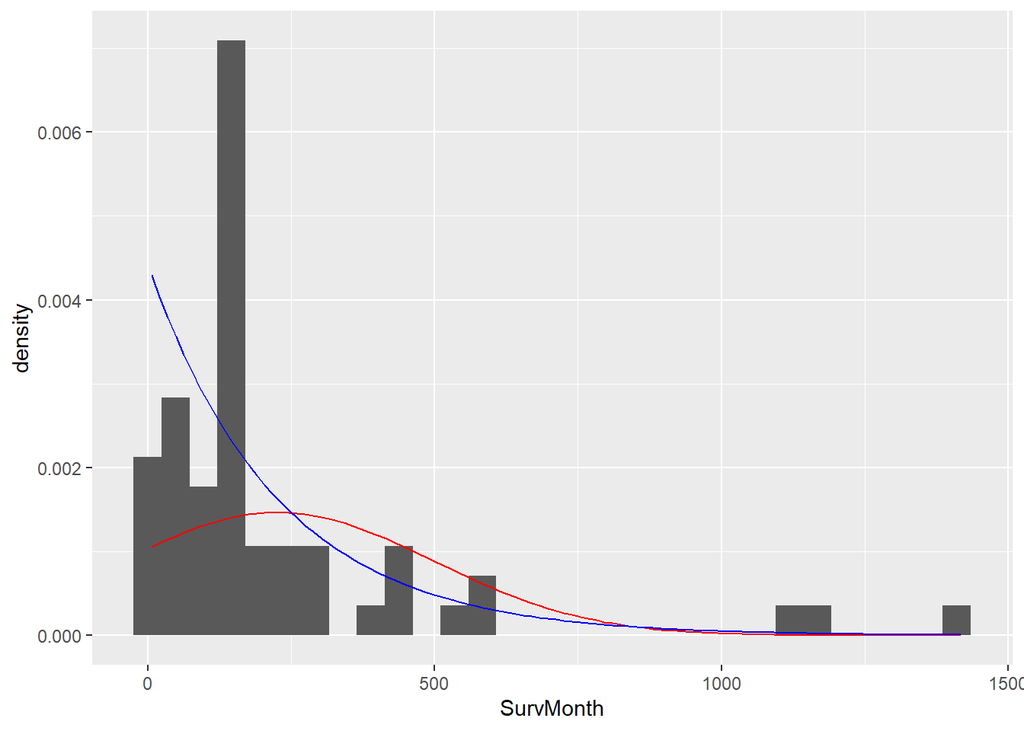

```r
library(ggplot2)

ggplot(data = Surv, mapping = aes(x=SurvMonth)) + geom_histogram(aes(y = after_stat(density))) +
  stat_function(fun = dnorm,
                args = list(mean = norm_ml$par[1], sd = norm_ml$par[2]),
                col = 'red') +
  stat_function(fun = dexp,
                args = list(rate = expon_ml$par),
                col = 'blue')
```

We can see that exponential fits better by having smaller minimized negative log-likelihood value, i.e.: smaller “*error*” at th end of the optimization process.

```r
expon_ml$value < norm_ml$value
```

```
## [1] TRUE
```

However, we need to **control for the fact that the normal distribution is more flexible as it has two parameters instead of one**. *!Note to self: describe over fitting!*

Hence the Information Criterion ($IC$). As all the $IC$s are **based on the negative log-likelihood, they always needs to be minimized**. So, the smaller $IC$ shows a better distribution fit.

Akaike ($AIC$), with $p$ being the number of estimated parameters:
$$2p-2l(\theta)$$

It’s easy to calculate in R.

```r
aic_exp <- 2*1 + 2*expon_ml$value # as the exponential distribution has p=1 parameter
aic_norm <- 2*2 + 2*norm_ml$value # as the normal distribution has p=2 parameters
```

And Bayes - Schwarz ($BIC$ or $SBC$):
$$p\ln(n) - 2l(\theta)$$

And implemented in R as follows.

```r
bic_exp <- 1*log(nrow(Surv)) + 2*expon_ml$value # as the exponential distribution has p=1 parameter
bic_norm  <- 2*log(nrow(Surv)) + 2*norm_ml$value # as the normal distribution has p=2 parameters
```

When calculating these two values, AIC and BIC show that the exponential is a better fit, despite having one parameter instead of two.

```r
aic_exp < aic_norm
```

```
## [1] TRUE
```

```r
bic_exp < bic_norm
```

```
## [1] TRUE
```

## 3. Automated Distribution Fitting with the `fitdistrplus` package

Install and load the package to your R environment.

```r
install.packages("fitdistrplus")
library(fitdistrplus)
```

Do the maximum likelihood fitting for normal and exponential distributions for the cancer survival data.

```r
fit_expon <- fitdist(Surv$SurvMonth, "exp", method = "mle")
```

```
## $start.arg
## $start.arg$rate
## [1] 0.004421379
##
##
## $fix.arg
## NULL
```

```r
fit_norm <- fitdist(Surv$SurvMonth, "norm", method = "mle")
```

```
## $start.arg
## $start.arg$mean
## [1] 226.1738
##
## $start.arg$sd
## [1] 271.5715
##
##
## $fix.arg
## NULL
```

```r
summary(fit_expon)
```

```
## Fitting of the distribution ' exp ' by maximum likelihood
## Parameters :
##         estimate Std. Error
## rate 0.004421379 0.00054886
## Loglikelihood:  -372.4356   AIC:  746.8712   BIC:  748.9317
```

```r
summary(fit_norm)
```

```
## Fitting of the distribution ' norm ' by maximum likelihood
## Parameters :
##      estimate Std. Error
## mean 226.1738   35.65910
## sd   271.5715   25.21502
## Loglikelihood:  -407.3435   AIC:  818.687   BIC:  822.8079
## Correlation matrix:
##      mean sd
## mean    1  0
## sd      0  1
```

You can see the standard errors, $SE$ for the estimated parameters! See that the $IC$s prefer the exponential fit.

And do a graphical comparison of the two fitted distributions on the histogram.

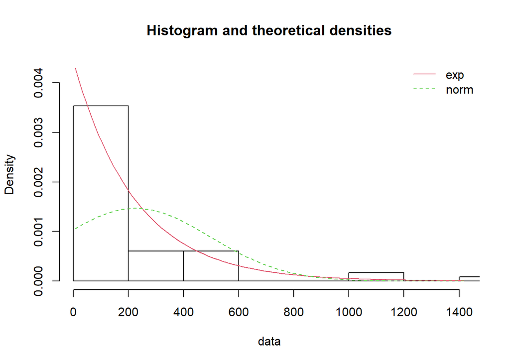

```r
denscomp(list(fit_expon, fit_norm))
```

Same result as with the ggplot in *Section 2*.